# BSMM-lab-3

BSMM 8740 Fall 2023

Author

Suhani Prajapati

Published

October 13, 2023

## Setup

Load packages and data:

```r
library(magrittr)   # the pipe
library(tidyverse)  # for data wrangling + visualization
library(tidymodels) # for modeling
library(gt)         # for pretty tables
#| message: false
#| Read the data
boston_cocktails <- readr::read_csv('data/boston_cocktails.csv')
```

## Exercises

### Exercise 1

```r
#view the data
#View(boston_cocktails)
```

```r
#Assess the quality of data
#install.packages("skimr")
library(skimr)
skimr::skim(boston_cocktails)
```

Data summary

| Name | boston_cocktails |
| --- | --- |
| Number of rows | 2542 |
| Number of columns | 7 |
| _______________________ |  |
| Column type frequency: |  |
| character | 4 |
| numeric | 3 |
| ________________________ |  |
| Group variables | None |

**Variable type: character**

| skim_variable | n_missing | complete_rate | min | max | empty | n_unique | whitespace |
| --- | --- | --- | --- | --- | --- | --- | --- |
| name | 0 | 1 | 4 | 36 | 0 | 937 | 0 |
| category | 0 | 1 | 3 | 21 | 0 | 11 | 0 |
| ingredient | 0 | 1 | 3 | 23 | 0 | 40 | 0 |
| measure | 0 | 1 | 1 | 8 | 0 | 28 | 0 |

**Variable type: numeric**

| skim_variable | n_missing | complete_rate | mean | sd | p0 | p25 | p50 | p75 | p100 | hist |
| --- | --- | --- | --- | --- | --- | --- | --- | --- | --- | --- |
| row_id | 0 | 1 | 495.37 | 284.75 | 1.00 | 261.25 | 497 | 730.75 | 990 | ▇▇▇▇▇ |
| ingredient_number | 0 | 1 | 2.54 | 1.29 | 1.00 | 1.00 | 2 | 3.00 | 6 | ▇▃▂▁▁ |
| measure_number | 0 | 1 | 0.98 | 0.72 | 0.02 | 0.50 | 1 | 1.50 | 16 | ▇▁▁▁▁ |

```r
#install.packages("DataExplorer")
library(DataExplorer)
boston_cocktails %>% DataExplorer::introduce()
```

```
# A tibble: 1 × 9
   rows columns discrete_columns continuous_columns all_missing_columns
  <int>   <int>            <int>              <int>               <int>
1  2542       7                4                  3                   0
# ℹ 4 more variables: total_missing_values <int>, complete_rows <int>,
#   total_observations <int>, memory_usage <dbl>
```

```r
boston_cocktails %>% summary()
```

```
     name             category             row_id      ingredient_number
 Length:2542        Length:2542        Min.   :  1.0   Min.   :1.000
 Class :character   Class :character   1st Qu.:261.2   1st Qu.:1.000
 Mode  :character   Mode  :character   Median :497.0   Median :2.000
                                       Mean   :495.4   Mean   :2.545
                                       3rd Qu.:730.8   3rd Qu.:3.000
                                       Max.   :990.0   Max.   :6.000
  ingredient          measure          measure_number
 Length:2542        Length:2542        Min.   : 0.0200
 Class :character   Class :character   1st Qu.: 0.5000
 Mode  :character   Mode  :character   Median : 1.0000
                                       Mean   : 0.9797
                                       3rd Qu.: 1.5000
                                       Max.   :16.0000
```

```r
#find the median
boston_cocktails %>%
  summarize(
    Median = median(measure_number)
  )
```

```
# A tibble: 1 × 1
  Median
   <dbl>
1      1
```

The median measure amount across all cocktails is **1**.

### Exercise 2

```r
#selecting the name, category, ingredients, measure_number
selected_items <- boston_cocktails %>% dplyr::select(name, category, ingredient, measure_number)
```

```r
#approach1: pivoting the table for each ingredients by grouping the ingredients and counting the number using summarize
#This only gives one column of ingredient.
#|pivoted_item <- selected_items %>%
#|group_by(ingredient) %>%
#|summarize(
#|count_of_ingredient = n()
#|)

#approach2: pivot_wider is used since it increases the number of columns and reduces the number of rows.
pivoted_item <- selected_items %>%
  pivot_wider(
    names_from = ingredient,
    values_from = measure_number,
    values_fill = 0
  )

pivoted_item
```

```
# A tibble: 937 × 42
   name         category `light rum` `lemon juice` `lime juice` `sweet vermouth`
   <chr>        <chr>          <dbl>         <dbl>        <dbl>            <dbl>
 1 Gauguin      Cocktai…        2             1            1                 0
 2 Fort Lauder… Cocktai…        1.5           0            0.25              0.5
 3 Cuban Cockt… Cocktai…        2             0            0.5               0
 4 Cool Carlos  Cocktai…        0             0            0                 0
 5 John Collins Whiskies        0             1            0                 0
 6 Cherry Rum   Cocktai…        1.25          0            0                 0
 7 Casa Blanca  Cocktai…        2             0            1.5               0
 8 Caribbean C… Cocktai…        0.5           0            0                 0
 9 Amber Amour  Cordial…        0             0.25         0                 0
10 The Joe Lew… Whiskies        0             0.5          0                 0
# ℹ 927 more rows
# ℹ 36 more variables: `orange juice` <dbl>, `powdered sugar` <dbl>,
#   `dark rum` <dbl>, `cranberry juice` <dbl>, `pineapple juice` <dbl>,
#   `bourbon whiskey` <dbl>, `simple syrup` <dbl>,
#   `cherry flavored brandy` <dbl>, `light cream` <dbl>, `triple sec` <dbl>,
#   maraschino <dbl>, amaretto <dbl>, grenadine <dbl>, `apple brandy` <dbl>,
#   brandy <dbl>, gin <dbl>, anisette <dbl>, `dry vermouth` <dbl>, …
```

```r
#install.packages("janitor")
library(janitor)
#clean the data and remove NA values
pivoted_item <- pivoted_item %>%
  janitor::clean_names() %>%
  drop_na()

pivoted_item
```

```
# A tibble: 937 × 42
   name    category light_rum lemon_juice lime_juice sweet_vermouth orange_juice
   <chr>   <chr>        <dbl>       <dbl>      <dbl>          <dbl>        <dbl>
 1 Gauguin Cocktai…      2           1          1               0           0
 2 Fort L… Cocktai…      1.5         0          0.25            0.5         0.25
 3 Cuban … Cocktai…      2           0          0.5             0           0
 4 Cool C… Cocktai…      0           0          0               0           1
 5 John C… Whiskies      0           1          0               0           0
 6 Cherry… Cocktai…      1.25        0          0               0           0
 7 Casa B… Cocktai…      2           0          1.5             0           0
 8 Caribb… Cocktai…      0.5         0          0               0           0
 9 Amber … Cordial…      0           0.25       0               0           0
10 The Jo… Whiskies      0           0.5        0               0           0
# ℹ 927 more rows
# ℹ 35 more variables: powdered_sugar <dbl>, dark_rum <dbl>,
#   cranberry_juice <dbl>, pineapple_juice <dbl>, bourbon_whiskey <dbl>,
#   simple_syrup <dbl>, cherry_flavored_brandy <dbl>, light_cream <dbl>,
#   triple_sec <dbl>, maraschino <dbl>, amaretto <dbl>, grenadine <dbl>,
#   apple_brandy <dbl>, brandy <dbl>, gin <dbl>, anisette <dbl>,
#   dry_vermouth <dbl>, apricot_flavored_brandy <dbl>, bitters <dbl>, …
```

```r
gin_leap_frog_highball <- pivoted_item %>%
  filter(name == "Leap Frog Highball") %>%
  select(gin)

gin_leap_frog_highball
```

```
# A tibble: 1 × 1
    gin
  <dbl>
1     2
```

The **Leap Frog Highball** contains **2** of gin

### Exercise 3

```r
#We'll use the cleaned pivoted data (pivoted_item) as our dataset.
library(recipes)
#create the recipe object
#Method1: directly use step_normalization method to normalize the predictors
recipe_model <- pivoted_item %>%
  recipe( ~ .) %>%
  update_role(name, category, new_role = 'id') %>%
  step_normalize(all_numeric()) %>%
  step_pca(all_numeric()) %>%
  prep()

summary(recipe_model)
```

```
# A tibble: 7 × 4
  variable type      role      source
  <chr>    <list>    <chr>     <chr>
1 name     <chr [3]> id        original
2 category <chr [3]> id        original
3 PC1      <chr [2]> predictor derived
4 PC2      <chr [2]> predictor derived
5 PC3      <chr [2]> predictor derived
6 PC4      <chr [2]> predictor derived
7 PC5      <chr [2]> predictor derived
```

```r
recipe_model
```

```
── Recipe ──────────────────────────────────────────────────────────────────────
```

```
── Inputs
```

```
Number of variables by role
```

```
predictor: 40
id:         2
```

```
── Training information
```

```
Training data contained 937 data points and no incomplete rows.
```

```
── Operations
```

```
• Centering and scaling for: light_rum, lemon_juice, lime_juice, ... | Trained
```

```
• PCA extraction with: light_rum, lemon_juice, lime_juice, ... | Trained
```

**40** predictor variables are prepped by the recipe.

```r
#Method2: add steps for normalization
#|recipe_model2 <- pivoted_item %>%
#|  recipe( ~ .) %>%
#|  update_role(name, category, new_role = 'id') %>%
#|  step_center(all_numeric()) %>%
#|  step_scale(all_numeric()) %>%
#|  step_pca(all_numeric()) %>%
#|  prep()

#|summary(recipe_model2)
#|recipe_model2
```

### Exercise 4

```r
recipe_model %>%
  recipes::tidy(1) %>%
  dplyr::arrange(desc(value))
```

```
# A tibble: 80 × 4
   terms            statistic value id
   <chr>            <chr>     <dbl> <chr>
 1 orange_juice     sd        0.776 normalize_2phGd
 2 gin              sd        0.564 normalize_2phGd
 3 light_rum        sd        0.477 normalize_2phGd
 4 vodka            sd        0.476 normalize_2phGd
 5 lemon_juice      sd        0.451 normalize_2phGd
 6 blanco_tequila   sd        0.407 normalize_2phGd
 7 lime_juice       sd        0.389 normalize_2phGd
 8 bourbon_whiskey  sd        0.374 normalize_2phGd
 9 grapefruit_juice sd        0.373 normalize_2phGd
10 brandy           sd        0.357 normalize_2phGd
# ℹ 70 more rows
```

```r
#recipe_model2 %>%
#  recipes::tidy(1) %>%
#  dplyr::arrange(desc(value))
```

### Exercise 5

```r
drinks <- recipe_model %>%
  recipes::tidy(2)
drinks_1_to_5 <- drinks %>%
  filter(component %in% c("PC1", "PC2", "PC3", "PC4", "PC5"))

drinks_1_to_5
```

```
# A tibble: 200 × 4
   terms             value component id
   <chr>             <dbl> <chr>     <chr>
 1 light_rum        0.163  PC1       pca_WTNMV
 2 lemon_juice     -0.0140 PC1       pca_WTNMV
 3 lime_juice       0.224  PC1       pca_WTNMV
 4 sweet_vermouth  -0.0661 PC1       pca_WTNMV
 5 orange_juice     0.0308 PC1       pca_WTNMV
 6 powdered_sugar  -0.476  PC1       pca_WTNMV
 7 dark_rum         0.124  PC1       pca_WTNMV
 8 cranberry_juice  0.0954 PC1       pca_WTNMV
 9 pineapple_juice  0.119  PC1       pca_WTNMV
10 bourbon_whiskey  0.0963 PC1       pca_WTNMV
# ℹ 190 more rows
```

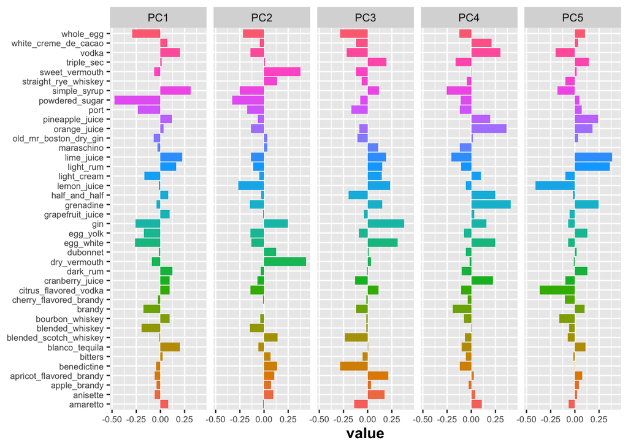

```r
drinks_1_to_5 %>%
  ggplot(aes(value, terms, fill = terms)) +
  geom_col(show.legend = FALSE) +
  facet_wrap(~component, nrow = 1) +
  labs(y = NULL) +
  theme(axis.text = element_text(size = 7),
        axis.title = element_text(size = 12, face = "bold"))
```

Describe the drinks represented by PC1?

**the drinks represented by PC1 are mostly syrupy and sweet with moderate to high alcohol content.**

### Exercise 6

```r
drinks %>%
  filter(component %in% c("PC1", "PC2", "PC3", "PC4")) %>%
  group_by(component) %>%
  slice_max(abs(value), n=8) %>%
  gt() %>%
  data_color(
    columns = c(value),
    colors = scales::col_numeric(
      palette = c("red", "yellow"),
      domain = c(-1,1)
    )
  )
```

| terms | value | id |
| --- | --- | --- |
| PC1 |  |  |
| powdered_sugar | -0.4764442 | pca_WTNMV |
| simple_syrup | 0.3125978 | pca_WTNMV |
| whole_egg | -0.2903794 | pca_WTNMV |
| egg_white | -0.2643614 | pca_WTNMV |
| gin | -0.2588481 | pca_WTNMV |
| port | -0.2354010 | pca_WTNMV |
| lime_juice | 0.2240295 | pca_WTNMV |
| blanco_tequila | 0.2025436 | pca_WTNMV |
| PC2 |  |  |
| dry_vermouth | 0.4332412 | pca_WTNMV |
| sweet_vermouth | 0.3754366 | pca_WTNMV |
| powdered_sugar | -0.3273723 | pca_WTNMV |
| lemon_juice | -0.2651836 | pca_WTNMV |
| simple_syrup | -0.2512150 | pca_WTNMV |
| gin | 0.2437374 | pca_WTNMV |
| whole_egg | -0.2191547 | pca_WTNMV |
| port | -0.1763370 | pca_WTNMV |
| PC3 |  |  |
| gin | 0.3780348 | pca_WTNMV |
| egg_white | 0.3094631 | pca_WTNMV |
| benedictine | -0.2864463 | pca_WTNMV |
| whole_egg | -0.2825812 | pca_WTNMV |
| blended_scotch_whiskey | -0.2352922 | pca_WTNMV |
| lemon_juice | 0.2318927 | pca_WTNMV |
| vodka | -0.2167814 | pca_WTNMV |
| apricot_flavored_brandy | 0.2134899 | pca_WTNMV |
| PC4 |  |  |
| grenadine | 0.4068737 | pca_WTNMV |
| orange_juice | 0.3625622 | pca_WTNMV |
| vodka | 0.3008406 | pca_WTNMV |
| simple_syrup | -0.2533007 | pca_WTNMV |
| half_and_half | 0.2493552 | pca_WTNMV |
| egg_white | 0.2465323 | pca_WTNMV |
| cranberry_juice | 0.2228099 | pca_WTNMV |
| white_creme_de_cacao | 0.2089063 | pca_WTNMV |

The characteristic alcoholic beverage of each of the first 4 principle components is **gin and vodka**.

### Exercise 7

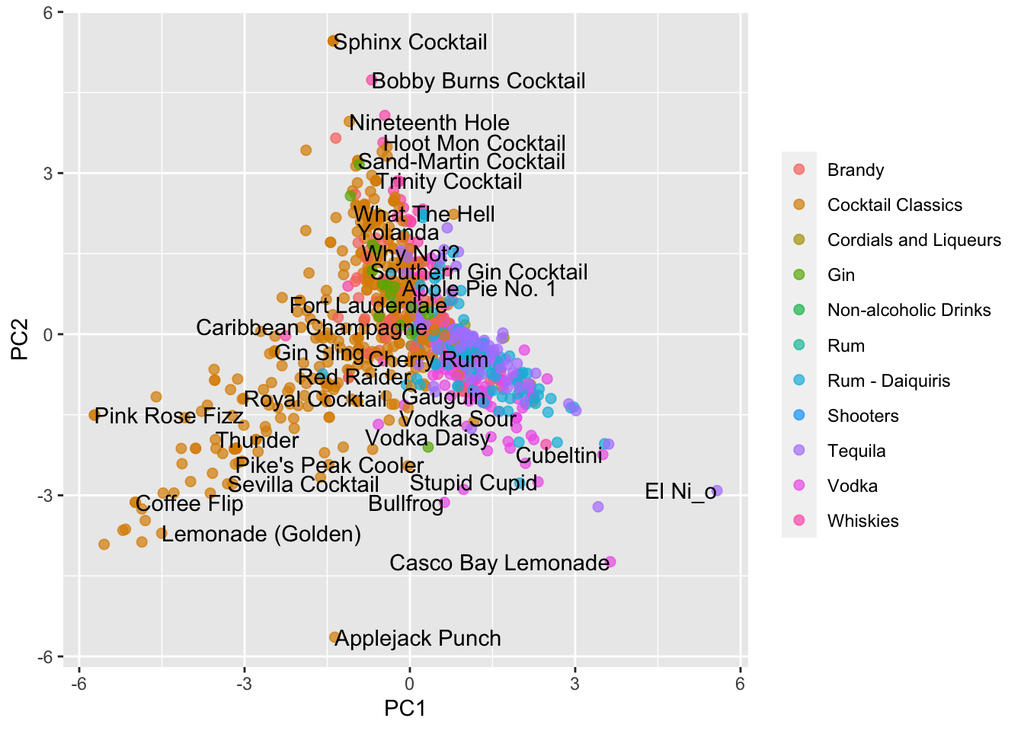

```r
recipes::bake(recipe_model, pivoted_item) %>%
  ggplot(aes(PC1, PC2, label = name)) +
  geom_point(aes(color = category), alpha = 0.7, size = 2) +
  geom_text(check_overlap = TRUE, hjust = "inward") +
  labs(color = NULL)
```

How would you interpret the results of a PCA analysis for a client?

**As per the graph, PC1 and PC2 do not focus on the cocktail classics or light cocktail classics as they have negative values for light cocktail classics. PC1 on one hand focuses on unmixed heavy alcohol and less on cocktails, on the other hand, PC2 focuses more on cocktail oriented drinks and less straightup alcohol.**